# Exercises 12 - Multiple Linear and Logistic Regression

# Exercise 2

Using the dataset `trees` in the package `datasets`, create a model to estimate the Volume of a tree based on the `Girth` and `Height` of the tree.

```r
#Load in required packages.
library(datasets)
```

Create plots to help you understand the relationship between `` Girth`` and ``Height`and`Volume```.

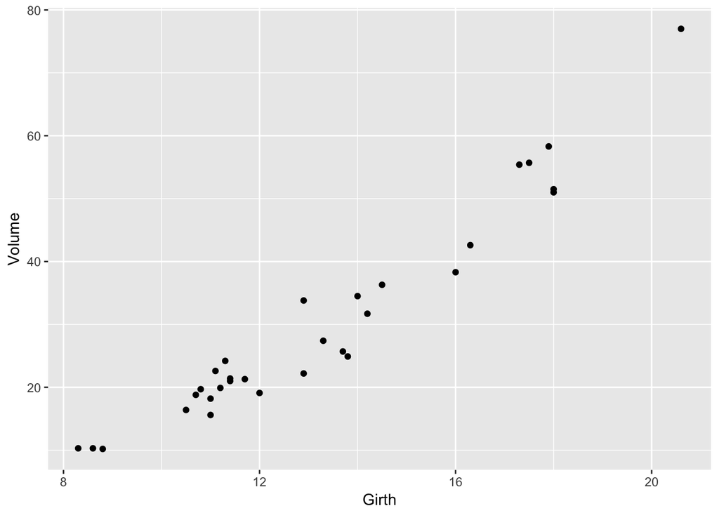

```r
# ?trees
# head(trees)

# visualization
# at first: see volume with respect to Girth
ggplot(data = trees, mapping = aes(x = Girth, y = Volume)) +
        geom_point()
```

```r
cor(trees$Girth, trees$Volume)
```

```
## [1] 0.9671194
```

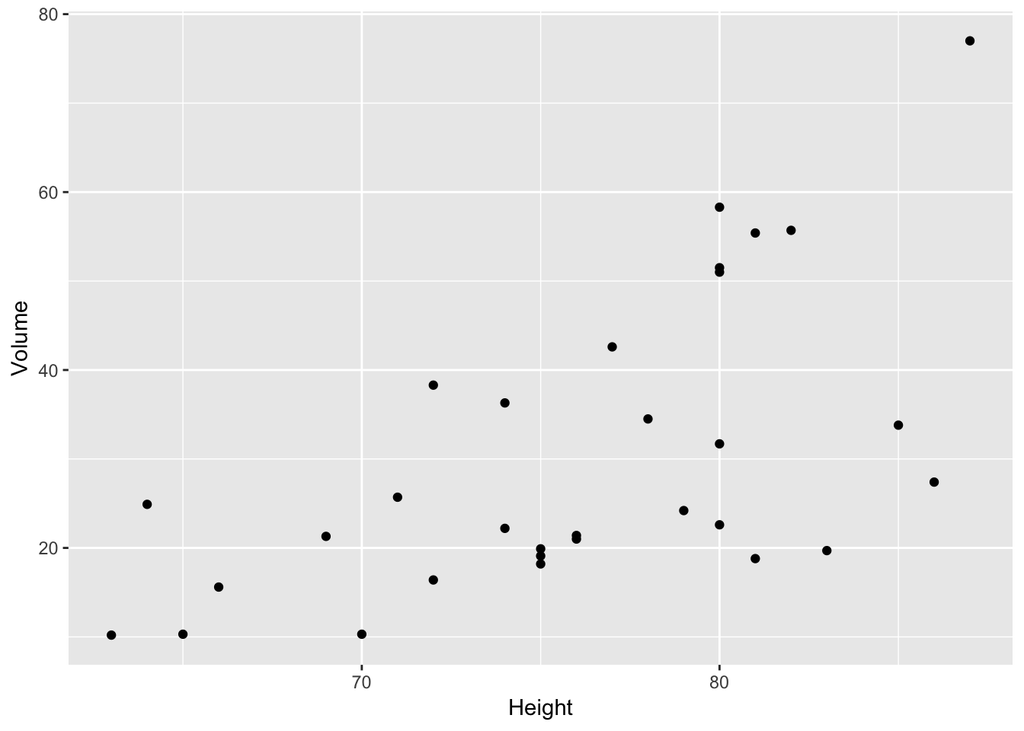

```r
#There is a very strong positive strength of the association between the Volume and the Girth of a tree (R = 0.9671194)

ggplot(data = trees, mapping = aes(x = Height, y = Volume)) +
        geom_point()
```

```r
cor(trees$Height, trees$Volume)
```

```
## [1] 0.5982497
```

```r
#There is a positive strength of the association between the Volume and the Height of a tree (R = 0.5982497)
```

Use the forward selection strategy to build a multiple linear model for the `Volume` using this dataset.

```r
fit4 <- lm(data = trees, Volume ~ Height + Girth)

summary(fit4)
```

```
##
## Call:
## lm(formula = Volume ~ Height + Girth, data = trees)
##
## Residuals:
##     Min      1Q  Median      3Q     Max
## -6.4065 -2.6493 -0.2876  2.2003  8.4847
##
## Coefficients:
##             Estimate Std. Error t value Pr(>|t|)
## (Intercept) -57.9877     8.6382  -6.713 2.75e-07 ***
## Height        0.3393     0.1302   2.607   0.0145 *
## Girth         4.7082     0.2643  17.816  < 2e-16 ***
## ---
## Signif. codes:  0 '***' 0.001 '**' 0.01 '*' 0.05 '.' 0.1 ' ' 1
##
## Residual standard error: 3.882 on 28 degrees of freedom
## Multiple R-squared:  0.948,  Adjusted R-squared:  0.9442
## F-statistic:   255 on 2 and 28 DF,  p-value: < 2.2e-16
```

Create graphics that will help you check the assumptions of the multiple linear regression model.

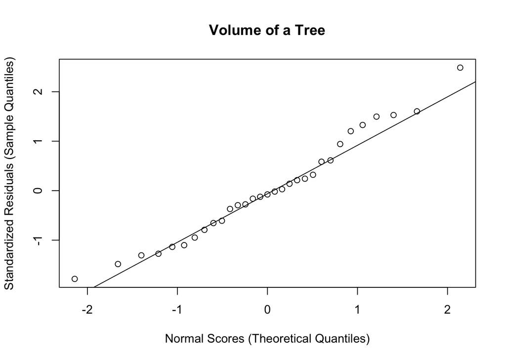

```r
# check the assumptions of Multi-Linear Regression
# 1. Residuals are nearly normal
fit.stdres = rstandard(fit4)
qqnorm(fit.stdres,
       ylab = "Standardized Residuals (Sample Quantiles)",
       xlab = "Normal Scores (Theoretical Quantiles)",
       main = "Volume of a Tree")

qqline(fit.stdres)
```